# Lab 2: Avocado Sales

Author

Diya Patel

Import the Kaggle dataset:

```python
import pandas as pd
import numpy as np
df_avocado = pd.read_csv("/Users/diyapatel/Downloads/avocado-updated-2020.csv")
print(df_avocado.head())
```

```
         date  average_price  total_volume       4046       4225      4770  \
0  2015-01-04           1.22      40873.28    2819.50   28287.42     49.90
1  2015-01-04           1.79       1373.95      57.42     153.88      0.00
2  2015-01-04           1.00     435021.49  364302.39   23821.16     82.15
3  2015-01-04           1.76       3846.69    1500.15     938.35      0.00
4  2015-01-04           1.08     788025.06   53987.31  552906.04  39995.03

   total_bags  small_bags  large_bags  xlarge_bags          type  year  \
0     9716.46     9186.93      529.53          0.0  conventional  2015
1     1162.65     1162.65        0.00          0.0       organic  2015
2    46815.79    16707.15    30108.64          0.0  conventional  2015
3     1408.19     1071.35      336.84          0.0       organic  2015
4   141136.68   137146.07     3990.61          0.0  conventional  2015

              geography
0                Albany
1                Albany
2               Atlanta
3               Atlanta
4  Baltimore/Washington
```

Briefly describe the dataset:

The dataset contains data on avocado prices and sales volume in multiple cities, states and regions of the US. Some of the relevant columns in the dataset include the date the avocados were observed, the average price of a single avocado, type, the year, the city or region of the observed avocado, total number of avocados sold and total number of avocados with PLU.

Clean the dataset:

```python
df_avocado.describe()
# there are no null values
```

|  | average_price | total_volume | 4046 | 4225 | 4770 | total_bags | small_bags | large_bags | xlarge_bags | year |
| --- | --- | --- | --- | --- | --- | --- | --- | --- | --- | --- |
| count | 33045.000000 | 3.304500e+04 | 3.304500e+04 | 3.304500e+04 | 3.304500e+04 | 3.304500e+04 | 3.304500e+04 | 3.304500e+04 | 3.304500e+04 | 33045.000000 |
| mean | 1.379941 | 9.683997e+05 | 3.023914e+05 | 2.797693e+05 | 2.148255e+04 | 3.646735e+05 | 2.501980e+05 | 1.067329e+05 | 7.742585e+03 | 2017.460887 |
| std | 0.378972 | 3.934533e+06 | 1.301026e+06 | 1.151052e+06 | 1.001607e+05 | 1.564004e+06 | 1.037734e+06 | 5.167226e+05 | 4.819803e+04 | 1.699747 |
| min | 0.440000 | 8.456000e+01 | 0.000000e+00 | 0.000000e+00 | 0.000000e+00 | 0.000000e+00 | 0.000000e+00 | 0.000000e+00 | 0.000000e+00 | 2015.000000 |
| 25% | 1.100000 | 1.511895e+04 | 7.673100e+02 | 2.712470e+03 | 0.000000e+00 | 9.121860e+03 | 6.478630e+03 | 4.662900e+02 | 0.000000e+00 | 2016.000000 |
| 50% | 1.350000 | 1.291170e+05 | 1.099477e+04 | 2.343600e+04 | 1.780900e+02 | 5.322224e+04 | 3.687699e+04 | 6.375860e+03 | 0.000000e+00 | 2017.000000 |
| 75% | 1.620000 | 5.058285e+05 | 1.190219e+05 | 1.352389e+05 | 5.096530e+03 | 1.744314e+05 | 1.206624e+05 | 4.041723e+04 | 8.044400e+02 | 2019.000000 |
| max | 3.250000 | 6.371614e+07 | 2.274362e+07 | 2.047057e+07 | 2.546439e+06 | 3.168919e+07 | 2.055041e+07 | 1.332760e+07 | 1.403184e+06 | 2020.000000 |

```python
df_avocado=df_avocado.dropna()
df_avocado = df_avocado.rename(columns={'4046':'small', '4225':'large', '4770':'xlarge'})
df_avocado
```

|  | date | average_price | total_volume | small | large | xlarge | total_bags | small_bags | large_bags | xlarge_bags | type | year | geography |
| --- | --- | --- | --- | --- | --- | --- | --- | --- | --- | --- | --- | --- | --- |
| 0 | 2015-01-04 | 1.22 | 40873.28 | 2819.50 | 28287.42 | 49.90 | 9716.46 | 9186.93 | 529.53 | 0.00 | conventional | 2015 | Albany |
| 1 | 2015-01-04 | 1.79 | 1373.95 | 57.42 | 153.88 | 0.00 | 1162.65 | 1162.65 | 0.00 | 0.00 | organic | 2015 | Albany |
| 2 | 2015-01-04 | 1.00 | 435021.49 | 364302.39 | 23821.16 | 82.15 | 46815.79 | 16707.15 | 30108.64 | 0.00 | conventional | 2015 | Atlanta |
| 3 | 2015-01-04 | 1.76 | 3846.69 | 1500.15 | 938.35 | 0.00 | 1408.19 | 1071.35 | 336.84 | 0.00 | organic | 2015 | Atlanta |
| 4 | 2015-01-04 | 1.08 | 788025.06 | 53987.31 | 552906.04 | 39995.03 | 141136.68 | 137146.07 | 3990.61 | 0.00 | conventional | 2015 | Baltimore/Washington |
| ... | ... | ... | ... | ... | ... | ... | ... | ... | ... | ... | ... | ... | ... |
| 33040 | 2020-11-29 | 1.47 | 1583056.27 | 67544.48 | 97996.46 | 2617.17 | 1414878.10 | 906711.52 | 480191.83 | 27974.75 | organic | 2020 | Total U.S. |
| 33041 | 2020-11-29 | 0.91 | 5811114.22 | 1352877.53 | 589061.83 | 19741.90 | 3790665.29 | 2197611.02 | 1531530.14 | 61524.13 | conventional | 2020 | West |
| 33042 | 2020-11-29 | 1.48 | 289961.27 | 13273.75 | 19341.09 | 636.51 | 256709.92 | 122606.21 | 134103.71 | 0.00 | organic | 2020 | West |
| 33043 | 2020-11-29 | 0.67 | 822818.75 | 234688.01 | 80205.15 | 10543.63 | 497381.96 | 285764.11 | 210808.02 | 809.83 | conventional | 2020 | West Tex/New Mexico |
| 33044 | 2020-11-29 | 1.35 | 24106.58 | 1236.96 | 617.80 | 1564.98 | 20686.84 | 17824.52 | 2862.32 | 0.00 | organic | 2020 | West Tex/New Mexico |

33045 rows × 13 columns

```python
df_avocado["geography"].value_counts()
```

```
geography
Albany                  612
Sacramento              612
Northeast               612
Northern New England    612
Orlando                 612
Philadelphia            612
Phoenix/Tucson          612
Pittsburgh              612
Plains                  612
Portland                612
Raleigh/Greensboro      612
Richmond/Norfolk        612
Roanoke                 612
San Diego               612
Atlanta                 612
San Francisco           612
Seattle                 612
South Carolina          612
South Central           612
Southeast               612
Spokane                 612
St. Louis               612
Syracuse                612
Tampa                   612
Total U.S.              612
West                    612
New York                612
New Orleans/Mobile      612
Nashville               612
Midsouth                612
Baltimore/Washington    612
Boise                   612
Boston                  612
Buffalo/Rochester       612
California              612
Charlotte               612
Chicago                 612
Cincinnati/Dayton       612
Columbus                612
Dallas/Ft. Worth        612
Denver                  612
Detroit                 612
Grand Rapids            612
Great Lakes             612
Harrisburg/Scranton     612
Hartford/Springfield    612
Houston                 612
Indianapolis            612
Jacksonville            612
Las Vegas               612
Los Angeles             612
Louisville              612
Miami/Ft. Lauderdale    612
West Tex/New Mexico     609
Name: count, dtype: int64
```

There should be 3 unique dataframes for geography. One for the national level (‘Total U.S’), one for region (‘West, etc’), and one for city

Replace the states to their respective regions

#Exercise 3 - which major geographical region sold the most total organic, small Hass avocados in 2017?

```python
#Map out the regions. List out all of the regions shown when you value_counts along with the states of California and South Carolina, they are also regions as well
df_avocado['small']=pd.to_numeric(df_avocado['small'], errors='coerce')
regions = ['Northeast', 'Northern New England', 'Plains', 'Southeast', 'West', 'Midsouth', 'Great Lakes', 'California', 'South Carolina', 'West Tex/New Mexico', 'South Central']
filter = df_avocado[
    (df_avocado["geography"].isin(regions)) &
    (df_avocado["type"] == "organic") &
    (df_avocado["year"] == 2017)
]

group_by=filter.groupby('geography')['small'].sum().sort_values(ascending=False)

print(group_by.sort_values(ascending=False))
```

```
geography
West                    1870206.29
South Central           1717104.19
California              1526290.58
Northeast                925832.36
Southeast                285124.34
Great Lakes              202487.68
Midsouth                 186395.50
Plains                   168583.40
West Tex/New Mexico      110910.95
South Carolina            18494.05
Northern New England       1249.48
Name: small, dtype: float64
```

The major geographical region that sold the most total organic, small Hass avocados in 2017 was in the West region. Since California is also apart of the west, it’s value would be added to that of the west.

4. Split the date variable into month, day, and year variables. In which month is the highest average volume of avocado sales?

```python
df_avocado['date'] = pd.to_datetime(df_avocado['date'])

df_avocado['year'] = df_avocado['date'].dt.year
df_avocado['month'] = df_avocado['date'].dt.month
df_avocado['day'] = df_avocado['date'].dt.day

df_avocado

group_by=(df_avocado.groupby('month')['total_volume'].mean().sort_values(ascending=False))

group_by
```

```
month
5     1.123632e+06
2     1.095374e+06
6     1.051247e+06
4     1.016582e+06
3     9.957150e+05
1     9.853122e+05
7     9.832681e+05
8     9.499249e+05
9     9.064773e+05
10    8.446863e+05
11    8.223470e+05
12    8.076695e+05
Name: total_volume, dtype: float64
```

May has the highest average volume of avocado sales

5. Which metro area geographical regions sold the most total avocados? Plot side-by-side box-plots of the total volume for only the five metro geographical regions with the highest averages for the total_volume variable.

```python
#Map out the regions. List out all of the cities shown when you value_counts

df_avocado['total_volume']=pd.to_numeric(df_avocado['total_volume'], errors='coerce')
metro_regions = ['Albany', 'Sacramento', 'Orlando', 'Philadelphia', 'Phoenix/Tucson', 'Pittsburgh', 'Portland',
'Raleigh/Greensboro', 'Richmond/Norfolk', 'Roanoke', 'San Diego', 'Atlanta', 'San Francisco', 'Seattle',
'Spokane', 'St. Louis', 'Syracuse', 'Tampa', 'New York', 'New Orleans/Mobile', 'Nashville', 'Baltimore/Washington', 'Boise',
'Boston', 'Buffalo/Rochester', 'Charlotte', 'Chicago', 'Cincinnati/Dayton', 'Columbus', 'Dallas/Ft. Worth', 'Denver',
'Detroit', 'Grand Rapids', 'Harrisburg/Scranton', 'Hartford/Springfield', 'Houston', 'Indianapolis', 'Jacksonville', 'Las Vegas', 'Los Angeles',
'Louisville', 'Miami/Ft. Lauderdale']

filter = df_avocado[
    (df_avocado["geography"].isin(metro_regions))]

group_by=filter.groupby('geography')['total_volume'].sum().sort_values(ascending=False)

print(group_by.sort_values(ascending=False))
```

```
geography
Los Angeles             9.593505e+08
New York                5.282452e+08
Dallas/Ft. Worth        4.362042e+08
Houston                 4.208438e+08
Phoenix/Tucson          3.825234e+08
Denver                  2.779295e+08
Baltimore/Washington    2.767646e+08
San Francisco           2.742169e+08
Chicago                 2.576650e+08
Miami/Ft. Lauderdale    2.317448e+08
Portland                2.135438e+08
Boston                  2.041325e+08
Seattle                 2.024026e+08
Atlanta                 1.989941e+08
San Diego               1.737644e+08
Philadelphia            1.584327e+08
Sacramento              1.492713e+08
Tampa                   1.486281e+08
Detroit                 1.400228e+08
Orlando                 1.359013e+08
Las Vegas               1.088508e+08
Raleigh/Greensboro      1.079793e+08
Hartford/Springfield    1.046050e+08
New Orleans/Mobile      9.466657e+07
Harrisburg/Scranton     9.397640e+07
Cincinnati/Dayton       9.273281e+07
Richmond/Norfolk        9.124998e+07
Charlotte               8.128127e+07
Nashville               7.745375e+07
Indianapolis            6.640588e+07
Columbus                6.593675e+07
St. Louis               6.316405e+07
Jacksonville            6.220746e+07
Grand Rapids            5.896980e+07
Roanoke                 5.517729e+07
Buffalo/Rochester       5.120092e+07
Pittsburgh              4.109569e+07
Louisville              3.489267e+07
Albany                  3.481634e+07
Spokane                 3.078100e+07
Boise                   3.035955e+07
Syracuse                2.412871e+07
Name: total_volume, dtype: float64
```

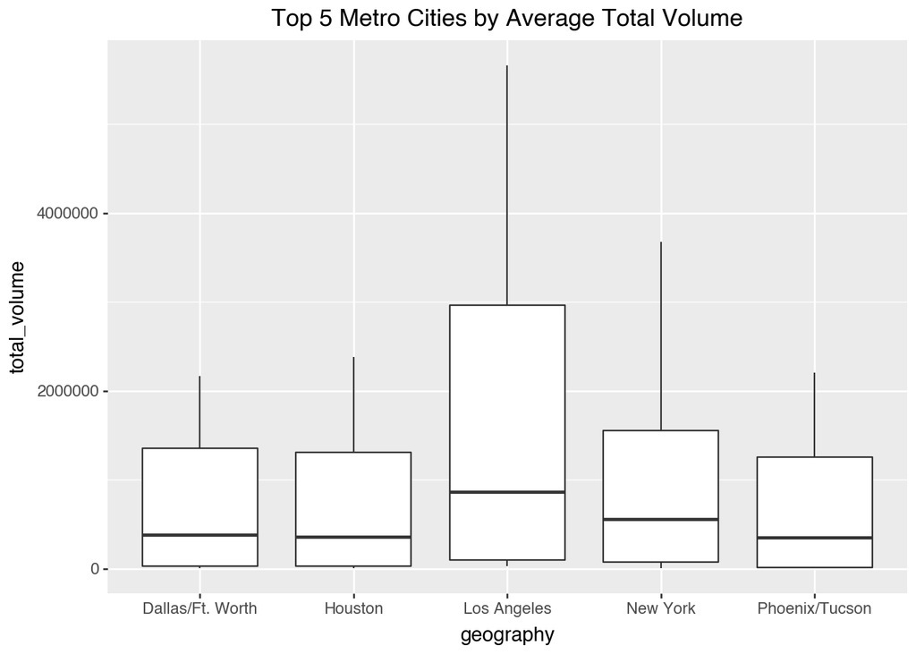

```python
import plotnine as p9
from plotnine import ggplot, aes, labs, geom_boxplot

city_avgs=filter.groupby('geography')['total_volume'].mean().sort_values(ascending=False)

top_5 = city_avgs.head(5).index

df_top_5 = filter[filter["geography"].isin(top_5)]

(
    ggplot(df_top_5, aes(x='geography', y='total_volume'))
    + geom_boxplot()
    + labs(title='Top 5 Metro Cities by Average Total Volume')
)
```

6. From the cleaned dataset, create a dataset with only California regions.

```python
california_region = ['Sacramento', 'Los Angeles', 'San Diego', 'San Francisco']

df_california = df_avocado[df_avocado['geography'].isin(california_region)]

california_mask = df_avocado['geography'].isin(california_region)
df_california = df_avocado[california_mask]
```

7. In which California regions is the price of organic versus conventional avocados most different?

```python
wide_prices = df_california.pivot_table(index="geography", columns='type', values='average_price', aggfunc='mean')

wide_prices

wide_prices['price_diff'] = wide_prices['organic'] - wide_prices['conventional']

wide_prices

wide_prices_sorted = wide_prices.sort_values(by='price_diff', ascending=False)

wide_prices_sorted
```

| type geography | conventional | organic | price_diff |
| --- | --- | --- | --- |
| San Francisco | 1.400490 | 2.119444 | 0.718954 |
| San Diego | 1.113856 | 1.798366 | 0.684510 |
| Sacramento | 1.295359 | 1.873856 | 0.578497 |
| Los Angeles | 1.047124 | 1.574902 | 0.527778 |

Summary Statistic

```python
statistics = df_california.groupby(['geography', 'type'])['average_price'].describe()
statistics
```

| geography | type | count | mean | std | min | 25% | 50% | 75% | max |
| --- | --- | --- | --- | --- | --- | --- | --- | --- | --- |
| Los Angeles | conventional | 306.0 | 1.047124 | 0.231167 | 0.53 | 0.8925 | 1.020 | 1.1475 | 1.80 |
|  | organic | 306.0 | 1.574902 | 0.311722 | 0.96 | 1.3425 | 1.585 | 1.7475 | 2.44 |
| Sacramento | conventional | 306.0 | 1.295359 | 0.219177 | 0.86 | 1.1325 | 1.260 | 1.4300 | 1.89 |
|  | organic | 306.0 | 1.873856 | 0.292875 | 1.13 | 1.6700 | 1.840 | 2.0475 | 2.82 |
| San Diego | conventional | 306.0 | 1.113856 | 0.242960 | 0.61 | 0.9425 | 1.090 | 1.2200 | 1.83 |
|  | organic | 306.0 | 1.798366 | 0.331655 | 1.05 | 1.5525 | 1.800 | 1.9975 | 2.78 |
| San Francisco | conventional | 306.0 | 1.400490 | 0.272060 | 0.84 | 1.2200 | 1.390 | 1.5675 | 2.20 |
|  | organic | 306.0 | 2.119444 | 0.395854 | 1.06 | 1.9025 | 2.060 | 2.3600 | 3.25 |

Plot

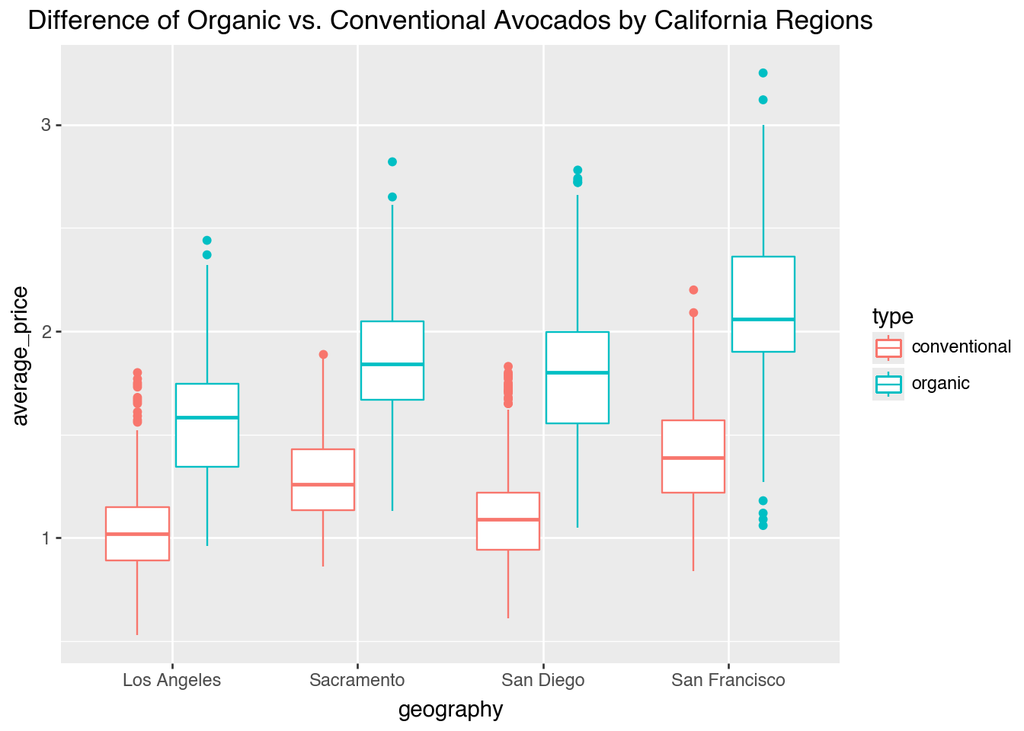

```python
import plotnine as p9
from plotnine import ggplot, aes, labs, geom_boxplot

# wide_prices_sorted=filter.groupby('geography')['price_diff'].mean().sort_values(ascending=False)
(
    ggplot(df_california, aes(x='geography', y='average_price', color='type'))
    + geom_boxplot()
    + labs(title='Difference of Organic vs. Conventional Avocados by California Regions')
)
```

San Francisco has the highest difference in prices of conventional vs organic avocados. This can be shown from the pivot table created that has been sorted by highest difference in prices of organic and conventional avocados in California. Furthermore, the boxplot shows us there is larger difference compared to other cities for the types of avocados. The summary statistic helps supplement the analysis by showing that San Francisco has the largest average price difference between organic and conventional avocados which is approximately $0.72 more for organic avocados.

8. Recreate the Proportion of Average Hass Avocado Sales by Size

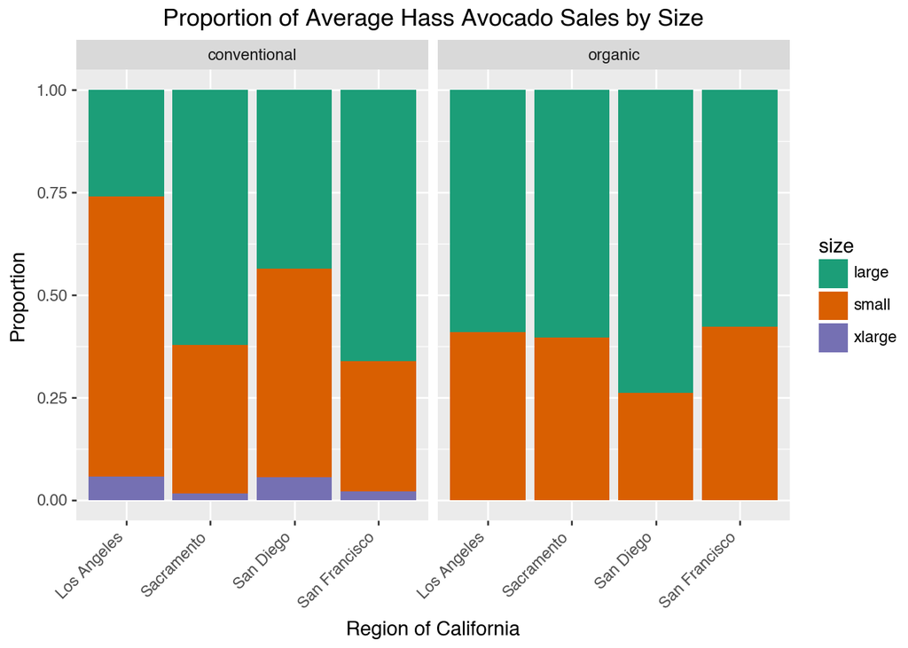

```python
import plotnine as p9
from plotnine import *

#define the colors
#used the colordrop feature in Google Docs to find the exact hue of the bar plot

(
    ggplot(
        df_california.melt(
            id_vars=['geography','type'],
            value_vars=['small','large','xlarge'],
            var_name='size',
            value_name='sales'
        ),
        aes('geography', 'sales', fill='size')
    )
    + geom_col(position='fill')
    + facet_wrap('~type')
    + scale_fill_manual(values={'xlarge':'#7570b3','large':'#1c9e78','small':'#d95f01'})
    #Used google docs to colordrop the colors of the graph
    + labs(title='Proportion of Average Hass Avocado Sales by Size',
           x='Region of California', y='Proportion')
    + theme(axis_text_x=element_text(angle=45, hjust=1))
)
```